# caseStudy2

Tadd Backus

2022-08-05

# Introduction and Overview

In this report, we explore the employee attrition dataset. This dataset contains employees who have either left a company or not as well as 37 different variables potentially relating to this. The steps and procedures taken for this analysis are detailed below. We start by looking at the most important factors for employee attrition and then any trends for different job roles. Finally, we create two prediction models, one classifier to predict attrition and one linear regression to predict monthly income.

# Useful Links

- [`GitHub`](https://github.com/taddbackus/CaseStudy2DDS): This link contains all of the data, R code, and power points.
- [‘Employee Attrition App’](https://tbackus.shinyapps.io/EmployeeAttrition/?_ga=2.59679213.1944325347.1659738568-2039603706.1659738568): This link contains an R Shiny app that allows the user to explore the attrition rates of different job roles and education fields, as well as the monthly income.
- [‘Presentation of Results - YouTube’](https://www.youtube.com/watch?v=iC9egHIgbzw): Video of the presentation of results of Employee Attrition analysis.
- [`README.md`](https://github.com/tadbackus/CaseStudy2DDS/blob/main/README.md): This page shows an introduction to the analysis we ran. It also includes a few details about the datasets provided.
- [`Beers.csv`](https://github.com/tadbackus/CaseStudy2DDS/blob/main/CaseStudy2-data.csv)

### This section looks at factors that have a large impact on employee attrition.

The bar graph below shows the amount of employees that left and stayed for each of the departments.

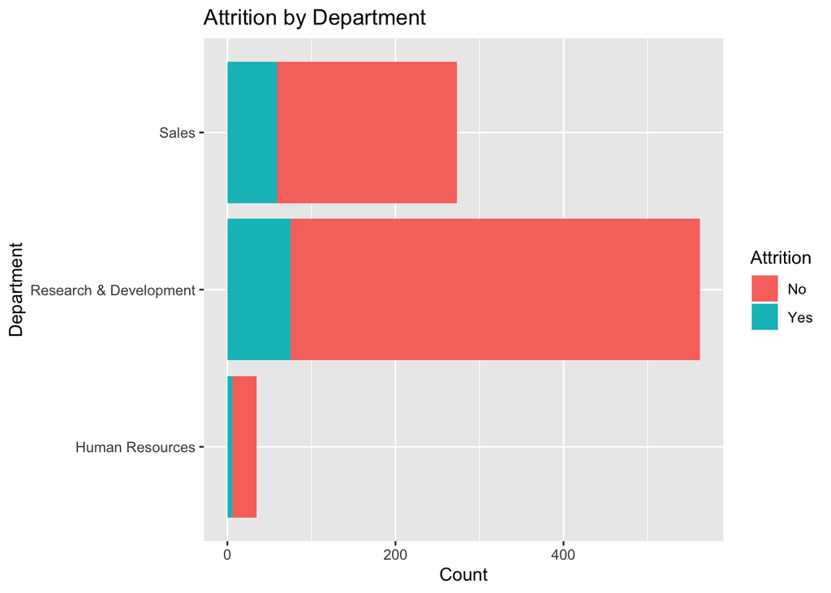

Below are the numbers for employees who left.

```
##        Human Resources Research & Development                  Sales
##                      6                     75                     59
```

Below are the numbers for employees who stayed

```
##        Human Resources Research & Development                  Sales
##                     29                    487                    214
```

The bar graph below shows the amount of employees that left and stayed for each individual job role.

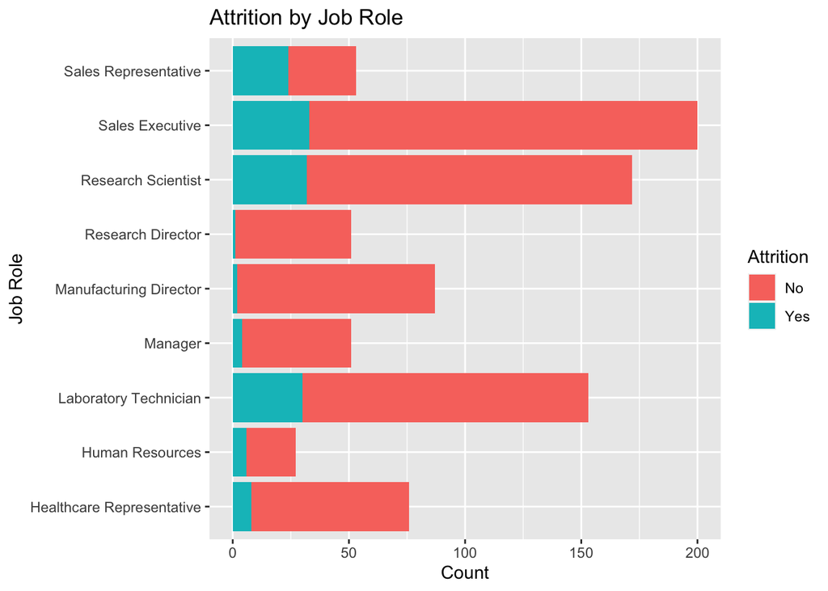

Below are the numbers for employees who left.

```
## Healthcare Representative           Human Resources     Laboratory Technician
##                         8                         6                        30
##                   Manager    Manufacturing Director         Research Director
##                         4                         2                         1
##        Research Scientist           Sales Executive      Sales Representative
##                        32                        33                        24
```

Below are the numbers for employees who stayed.

```
## Healthcare Representative           Human Resources     Laboratory Technician
##                        68                        21                       123
##                   Manager    Manufacturing Director         Research Director
##                        47                        85                        50
##        Research Scientist           Sales Executive      Sales Representative
##                       140                       167                        29
```

This plot shows combinations of education field and job role and whether or not the employee left.

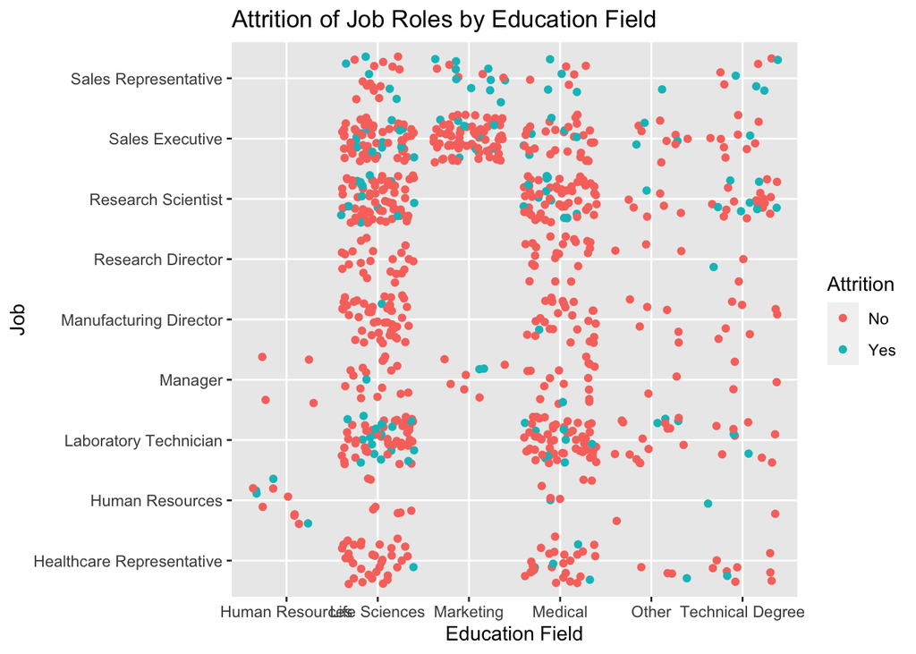

These graphs show the distributions of log transformed monthly incomes for the corresponding attrition.

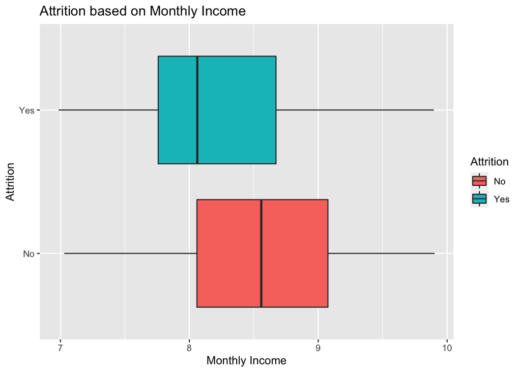

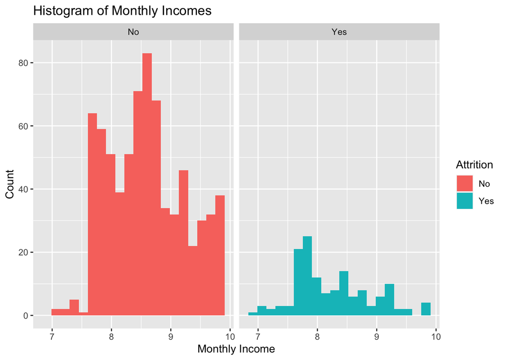

The results of a two sample t-test on the monthly income data.

```
##
##  Two Sample t-test
##
## data:  log(attrY$MonthlyIncome) and log(attrN$MonthlyIncome)
## t = -5.9707, df = 868, p-value = 0.000000003442
## alternative hypothesis: true difference in means is not equal to 0
## 95 percent confidence interval:
##  -0.4748425 -0.2398918
## sample estimates:
## mean of x mean of y
##  8.237820  8.595187
```

This barplot shows how many employees left based on whether or not they worked over time.

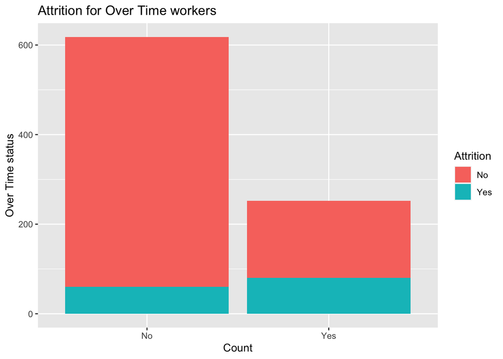

Below are the numbers for employees who left.

```
##  No Yes
##  60  80
```

Below are the numbers for employees who stayed.

```
##  No Yes
## 558 172
```

This boxplot shows the distribution of monthly incomes for each job role.

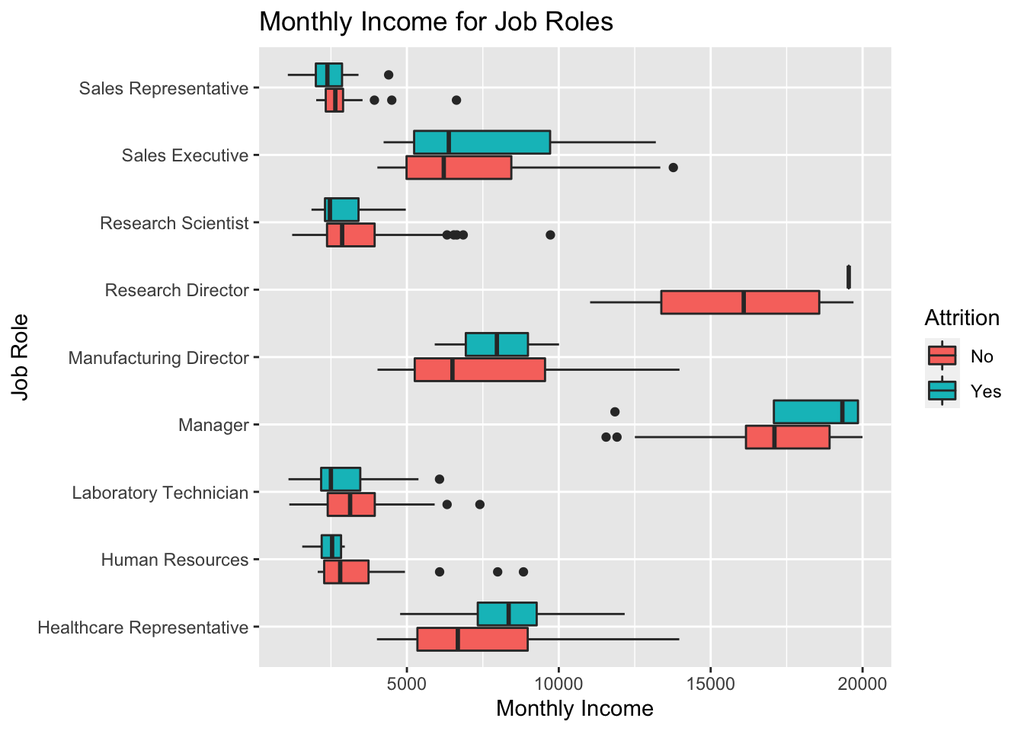

Plotting job satisfaction for each job role.

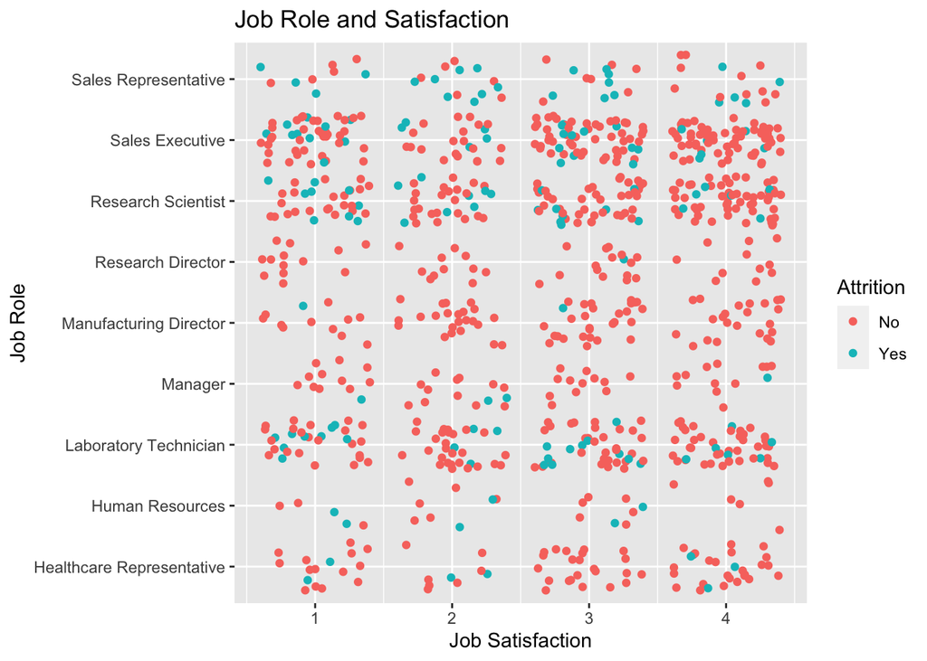

Variables used in the “Happiness” kNN Model.

```
##  Attrition      Age        DistanceFromHome EnvironmentSatisfaction
##  No :730   Min.   :18.00   Min.   : 1.000   Min.   :1.000
##  Yes:140   1st Qu.:30.00   1st Qu.: 2.000   1st Qu.:2.000
##            Median :35.00   Median : 7.000   Median :3.000
##            Mean   :36.83   Mean   : 9.339   Mean   :2.701
##            3rd Qu.:43.00   3rd Qu.:14.000   3rd Qu.:4.000
##            Max.   :60.00   Max.   :29.000   Max.   :4.000
##  JobSatisfaction RelationshipSatisfaction WorkLifeBalance
##  Min.   :1.000   Min.   :1.000            Min.   :1.000
##  1st Qu.:2.000   1st Qu.:2.000            1st Qu.:2.000
##  Median :3.000   Median :3.000            Median :3.000
##  Mean   :2.709   Mean   :2.707            Mean   :2.782
##  3rd Qu.:4.000   3rd Qu.:4.000            3rd Qu.:3.000
##  Max.   :4.000   Max.   :4.000            Max.   :4.000
```

Variables used in the “Pay” kNN Model.

```
##  Attrition      Age          DailyRate        HourlyRate     MonthlyIncome
##  No :730   Min.   :18.00   Min.   : 103.0   Min.   : 30.00   Min.   : 1081
##  Yes:140   1st Qu.:30.00   1st Qu.: 472.5   1st Qu.: 48.00   1st Qu.: 2840
##            Median :35.00   Median : 817.5   Median : 66.00   Median : 4946
##            Mean   :36.83   Mean   : 815.2   Mean   : 65.61   Mean   : 6390
##            3rd Qu.:43.00   3rd Qu.:1165.8   3rd Qu.: 83.00   3rd Qu.: 8182
##            Max.   :60.00   Max.   :1499.0   Max.   :100.00   Max.   :19999
##   MonthlyRate    PercentSalaryHike PerformanceRating StockOptionLevel
##  Min.   : 2094   Min.   :11.0      Min.   :3.000     Min.   :0.0000
##  1st Qu.: 8092   1st Qu.:12.0      1st Qu.:3.000     1st Qu.:0.0000
##  Median :14074   Median :14.0      Median :3.000     Median :1.0000
##  Mean   :14326   Mean   :15.2      Mean   :3.152     Mean   :0.7839
##  3rd Qu.:20456   3rd Qu.:18.0      3rd Qu.:3.000     3rd Qu.:1.0000
##  Max.   :26997   Max.   :25.0      Max.   :4.000     Max.   :3.0000
```

Variables used in the “Experience” kNN Model.

```
##  Attrition      Age          Education        JobLevel     JobInvolvement
##  No :730   Min.   :18.00   Min.   :1.000   Min.   :1.000   Min.   :1.000
##  Yes:140   1st Qu.:30.00   1st Qu.:2.000   1st Qu.:1.000   1st Qu.:2.000
##            Median :35.00   Median :3.000   Median :2.000   Median :3.000
##            Mean   :36.83   Mean   :2.901   Mean   :2.039   Mean   :2.723
##            3rd Qu.:43.00   3rd Qu.:4.000   3rd Qu.:3.000   3rd Qu.:3.000
##            Max.   :60.00   Max.   :5.000   Max.   :5.000   Max.   :4.000
##  JobSatisfaction NumCompaniesWorked TotalWorkingYears TrainingTimesLastYear
##  Min.   :1.000   Min.   :0.000      Min.   : 0.00     Min.   :0.000
##  1st Qu.:2.000   1st Qu.:1.000      1st Qu.: 6.00     1st Qu.:2.000
##  Median :3.000   Median :2.000      Median :10.00     Median :3.000
##  Mean   :2.709   Mean   :2.728      Mean   :11.05     Mean   :2.832
##  3rd Qu.:4.000   3rd Qu.:4.000      3rd Qu.:15.00     3rd Qu.:3.000
##  Max.   :4.000   Max.   :9.000      Max.   :40.00     Max.   :6.000
##  YearsAtCompany   YearsInCurrentRole YearsSinceLastPromotion
##  Min.   : 0.000   Min.   : 0.000     Min.   : 0.000
##  1st Qu.: 3.000   1st Qu.: 2.000     1st Qu.: 0.000
##  Median : 5.000   Median : 3.000     Median : 1.000
##  Mean   : 6.962   Mean   : 4.205     Mean   : 2.169
##  3rd Qu.:10.000   3rd Qu.: 7.000     3rd Qu.: 3.000
##  Max.   :40.000   Max.   :18.000     Max.   :15.000
##  YearsWithCurrManager
##  Min.   : 0.00
##  1st Qu.: 2.00
##  Median : 3.00
##  Mean   : 4.14
##  3rd Qu.: 7.00
##  Max.   :17.00
```

Variables used in the “Happiness” Naive Bayes Model.

```
##  Attrition      Age        DistanceFromHome EnvironmentSatisfaction
##  No :730   Min.   :18.00   Min.   : 1.000   Min.   :1.000
##  Yes:140   1st Qu.:30.00   1st Qu.: 2.000   1st Qu.:2.000
##            Median :35.00   Median : 7.000   Median :3.000
##            Mean   :36.83   Mean   : 9.339   Mean   :2.701
##            3rd Qu.:43.00   3rd Qu.:14.000   3rd Qu.:4.000
##            Max.   :60.00   Max.   :29.000   Max.   :4.000
##
##  JobSatisfaction RelationshipSatisfaction WorkLifeBalance    Gender
##  Min.   :1.000   Min.   :1.000            Min.   :1.000   Female:354
##  1st Qu.:2.000   1st Qu.:2.000            1st Qu.:2.000   Male  :516
##  Median :3.000   Median :3.000            Median :3.000
##  Mean   :2.709   Mean   :2.707            Mean   :2.782
##  3rd Qu.:4.000   3rd Qu.:4.000            3rd Qu.:3.000
##  Max.   :4.000   Max.   :4.000            Max.   :4.000
##
##                       JobRole    OverTime   MaritalStatus
##  Sales Executive          :200   No :618   Divorced:191
##  Research Scientist       :172   Yes:252   Married :410
##  Laboratory Technician    :153             Single  :269
##  Manufacturing Director   : 87
##  Healthcare Representative: 76
##  Sales Representative     : 53
##  (Other)                  :129
```

Variables used in the “Pay” Naive Bayes Model.

```
##  Attrition      Age          DailyRate        HourlyRate     MonthlyIncome
##  No :730   Min.   :18.00   Min.   : 103.0   Min.   : 30.00   Min.   : 1081
##  Yes:140   1st Qu.:30.00   1st Qu.: 472.5   1st Qu.: 48.00   1st Qu.: 2840
##            Median :35.00   Median : 817.5   Median : 66.00   Median : 4946
##            Mean   :36.83   Mean   : 815.2   Mean   : 65.61   Mean   : 6390
##            3rd Qu.:43.00   3rd Qu.:1165.8   3rd Qu.: 83.00   3rd Qu.: 8182
##            Max.   :60.00   Max.   :1499.0   Max.   :100.00   Max.   :19999
##
##   MonthlyRate    PercentSalaryHike PerformanceRating StockOptionLevel
##  Min.   : 2094   Min.   :11.0      Min.   :3.000     Min.   :0.0000
##  1st Qu.: 8092   1st Qu.:12.0      1st Qu.:3.000     1st Qu.:0.0000
##  Median :14074   Median :14.0      Median :3.000     Median :1.0000
##  Mean   :14326   Mean   :15.2      Mean   :3.152     Mean   :0.7839
##  3rd Qu.:20456   3rd Qu.:18.0      3rd Qu.:3.000     3rd Qu.:1.0000
##  Max.   :26997   Max.   :25.0      Max.   :4.000     Max.   :3.0000
##
##                   Department           EducationField    Gender
##  Human Resources       : 35   Human Resources : 15    Female:354
##  Research & Development:562   Life Sciences   :358    Male  :516
##  Sales                 :273   Marketing       :100
##                               Medical         :270
##                               Other           : 52
##                               Technical Degree: 75
##
##                       JobRole
##  Sales Executive          :200
##  Research Scientist       :172
##  Laboratory Technician    :153
##  Manufacturing Director   : 87
##  Healthcare Representative: 76
##  Sales Representative     : 53
##  (Other)                  :129
```

Variables used in the “Experience” Naive Bayes Model.

```
##  Attrition      Age          Education        JobLevel     JobInvolvement
##  No :730   Min.   :18.00   Min.   :1.000   Min.   :1.000   Min.   :1.000
##  Yes:140   1st Qu.:30.00   1st Qu.:2.000   1st Qu.:1.000   1st Qu.:2.000
##            Median :35.00   Median :3.000   Median :2.000   Median :3.000
##            Mean   :36.83   Mean   :2.901   Mean   :2.039   Mean   :2.723
##            3rd Qu.:43.00   3rd Qu.:4.000   3rd Qu.:3.000   3rd Qu.:3.000
##            Max.   :60.00   Max.   :5.000   Max.   :5.000   Max.   :4.000
##  JobSatisfaction NumCompaniesWorked TotalWorkingYears TrainingTimesLastYear
##  Min.   :1.000   Min.   :0.000      Min.   : 0.00     Min.   :0.000
##  1st Qu.:2.000   1st Qu.:1.000      1st Qu.: 6.00     1st Qu.:2.000
##  Median :3.000   Median :2.000      Median :10.00     Median :3.000
##  Mean   :2.709   Mean   :2.728      Mean   :11.05     Mean   :2.832
##  3rd Qu.:4.000   3rd Qu.:4.000      3rd Qu.:15.00     3rd Qu.:3.000
##  Max.   :4.000   Max.   :9.000      Max.   :40.00     Max.   :6.000
##  YearsAtCompany   YearsInCurrentRole YearsSinceLastPromotion
##  Min.   : 0.000   Min.   : 0.000     Min.   : 0.000
##  1st Qu.: 3.000   1st Qu.: 2.000     1st Qu.: 0.000
##  Median : 5.000   Median : 3.000     Median : 1.000
##  Mean   : 6.962   Mean   : 4.205     Mean   : 2.169
##  3rd Qu.:10.000   3rd Qu.: 7.000     3rd Qu.: 3.000
##  Max.   :40.000   Max.   :18.000     Max.   :15.000
##  YearsWithCurrManager
##  Min.   : 0.00
##  1st Qu.: 2.00
##  Median : 3.00
##  Mean   : 4.14
##  3rd Qu.: 7.00
##  Max.   :17.00
```

Combined model = (weighted kNN + weighted NB)/2 Weighted kNN = happiness X 0.6 + pay X 0.2 + experience X 0.2 Weight NB = happines X 0.4 + pay X 0.2 + experience X 0.4

Creating the linear regression model to predict monthly income. Variables used in the model.

```
##
## Call:
## lm(formula = MonthlyIncome ~ JobLevel + JobRole + TotalWorkingYears +
##     DistanceFromHome + Age + PerformanceRating + YearsAtCompany +
##     YearsSinceLastPromotion + OverTime, data = aDF)
##
## Residuals:
##     Min      1Q  Median      3Q     Max
## -3809.2  -652.7    -2.3   605.2  4085.2
##
## Coefficients:
##                               Estimate Std. Error t value             Pr(>|t|)
## (Intercept)                    430.165    428.164   1.005             0.315339
## JobLevel                      2803.826     82.588  33.949 < 0.0000000000000002
## JobRoleHuman Resources        -314.398    251.688  -1.249             0.211949
## JobRoleLaboratory Technician  -588.779    169.239  -3.479             0.000529
## JobRoleManager                4004.981    230.411  17.382 < 0.0000000000000002
## JobRoleManufacturing Director  153.675    167.247   0.919             0.358433
## JobRoleResearch Director      3988.550    216.699  18.406 < 0.0000000000000002
## JobRoleResearch Scientist     -325.878    169.673  -1.921             0.055112
## JobRoleSales Executive         -65.892    144.077  -0.457             0.647541
## JobRoleSales Representative   -446.475    212.453  -2.102             0.035888
## TotalWorkingYears               50.504     10.368   4.871           0.00000132
## DistanceFromHome                -7.374      4.458  -1.654             0.098475
## Age                             -1.482      5.489  -0.270             0.787297
## PerformanceRating             -131.463    101.230  -1.299             0.194411
## YearsAtCompany                 -14.488      9.325  -1.554             0.120641
## YearsSinceLastPromotion         24.776     14.929   1.660             0.097375
## OverTimeYes                     19.586     80.234   0.244             0.807203
##
## (Intercept)
## JobLevel                      ***
## JobRoleHuman Resources
## JobRoleLaboratory Technician  ***
## JobRoleManager                ***
## JobRoleManufacturing Director
## JobRoleResearch Director      ***
## JobRoleResearch Scientist     .
## JobRoleSales Executive
## JobRoleSales Representative   *
## TotalWorkingYears             ***
## DistanceFromHome              .
## Age
## PerformanceRating
## YearsAtCompany
## YearsSinceLastPromotion       .
## OverTimeYes
## ---
## Signif. codes:  0 '***' 0.001 '**' 0.01 '*' 0.05 '.' 0.1 ' ' 1
##
## Residual standard error: 1061 on 853 degrees of freedom
## Multiple R-squared:  0.9477, Adjusted R-squared:  0.9467
## F-statistic: 965.6 on 16 and 853 DF,  p-value: < 0.00000000000000022
```

Performance of the model

```
##              CV             AIC            AICc             BIC           AdjR2
## 1148305.0815687   12142.1447273   12142.9484876   12227.9776051       0.9466979
```

RMSE of the linear regression model

```
## [1] 1051.06
```

Plot of fitted values for monthly income and the originals

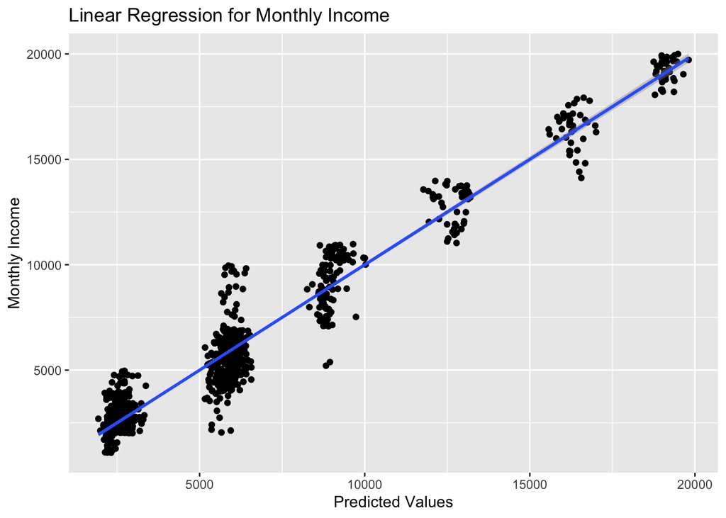